# Презентация по лабораторной работе 2

Основы информационной безопасности

Нджову Н.

Российский университет дружбы народов, Москва, Россия

28 февралья 2025

## Цель работы

Получение практических навыков работы в консоли с атрибутами файлов, закрепление теоретических основ дискреционного разграничения доступа в современных системах с открытым кодом на базе ОС Linux1.

## Выполнение лабораторной работы

В операционной систем, которую я установила во время предыдущей лабораторной работы, я создаю учетную запись пользователя guest, используя учетную запись администратора(рис.1).

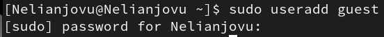

Создание пользователя

## Выполнение лабораторной работы

Я задаю пароль для нового пользователя guest(рис.2)

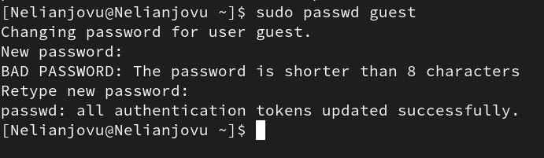

Создание пароля

## Выполнение лабораторной работы

Затем я вхожу в систему как гость(рис.3)

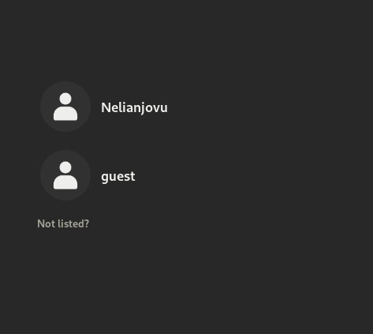

вход в системе

## Выполнение лабораторной работы

Я использую команду pwd, чтобы определить каталог, в котором я нахожусь. После сравнения с запросом командной строки, я вижу что уже нахожусь в домашнем каталог(рис.4)

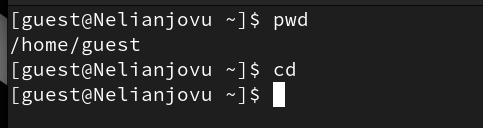

Текущая директория

## Выполнение лабораторной работы

Я указываю имя пользователя с помощью команды whoami(рис.5)

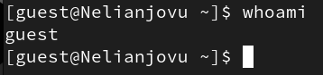

Информация об имени пользователе

## Выполнение лабораторной работы

Я указываю имя пользователя, группу и группы, к которым принадлежит пользователь, с помощью команды id. Команда group выдает мне только имя пользователя, но с помощью команды id я получаю больше информации (информация, указанная выше)(рис.6)

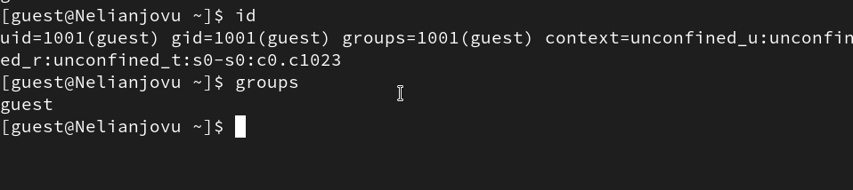

Информация о пользователе

## Выполнение лабораторной работы

Имя пользователя, которое я получаю после запуска команды whoami, совпадает с именем пользователя в приглашении командной строкой(рис.7)

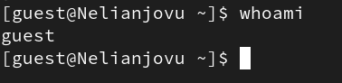

Информация об имени пользователе

## Выполнение лабораторной работы

Я просматриваю файл /etc/passwd с помощью Cat /etc/passwd | Grep guest команда. Вывод, который я получаю, - это коды имени пользователя и группы, а также адрес для моего домашнего каталога(рис.8)

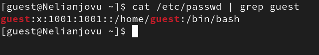

Просмотр файла

## Выполнение лабораторной работы

Я определяю существующие каталоги в системе с помощью команды ls -l /home/. Мне удалось получить список поддиректории имени пользователя и группы каталогов каталога /home, а также права доступа(рис.9)

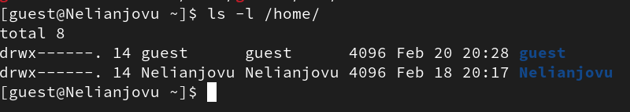

Просмотр директории

## Выполнение лабораторной работы

Я попытался проверить, какие расширенные атрибуты установлены в подкаталогах, расположенных в каталоге /home, с помощью команды: lsattr/home, но не удалось увидеть расширенные атрибуты каталога(рис.10)

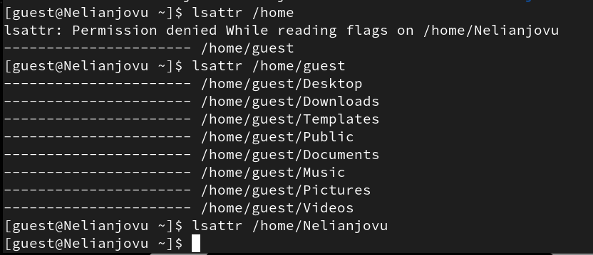

Проверка расширенных атрибутов

## Выполнение лабораторной работы

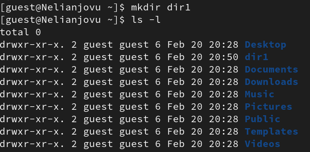

## Выполнение лабораторной работы

Я удаляю все атрибуты из каталога dir1 с помощью команды chmod 000 dir1 и с помощью ls -l проверьте правильность выполнения команды(рис.12)

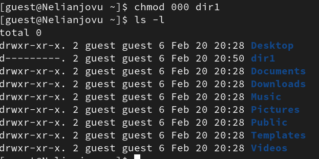

Снятие атрибутов с директории

## Выполнение лабораторной работы

Попытка создать файл в директории dir1. Выдает ошибку: “Permission denied”(рис.13)

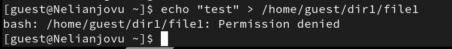

Попытка создания файла

## Выполнение лабораторной работы

Вернув права директории и использовав снова командy ls -l можно убедиться, что файл не был создан(рис.14)

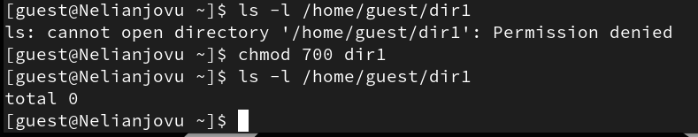

Проверка содержимого директории

## Выполнение лабораторной работы

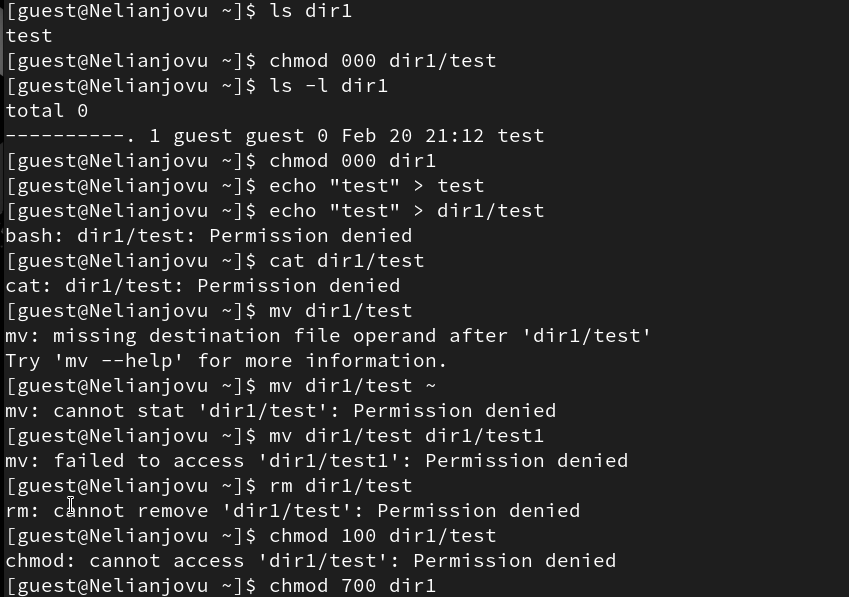

Изменение прав директории и файла

## Выполнение лабораторной работы

| Операция | Минимальные права на директорию | Минимальные права на файл |  |  |
| --- | --- | --- | --- | --- |
| Создание файла | d(300) | - |  |  |
| Удаление файла | d(300) | - |  |  |
| Чтение файла | d(100) | (400) |  |  |
| Запись в файл | d(100) | (200) |  |  |
| Переименование файла | d(300) | (000) |  |  |
| Создание поддиректории | d(300) | - |  |  |
| Удаление поддиректории | d(300) | - |  |  |

Таблица 2.2 “Минимальные права для совершения операций”

## Выполнение лабораторной работы

Пример заполнения таблицы 2.2 (рис.16)

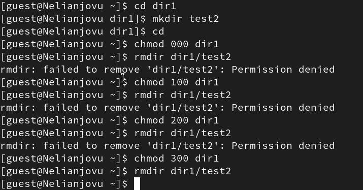

## Выводы

Выполнив эту работу я получила практические навыки работы в консоли с атрибутами файлов, закрепление теоретических основ дискреционного разграничения доступа в современных системах с открытым кодом на базе ОС Linux1.